# Demonstration of Generic Target Shuffling

David Marx

September 15, 2014

Target shuffling is an extremely simple algorithm for estimating the significance of a model. The idea is to use resampling to estimate the distribution of a given test statistic under the null hypothesis, and then compare our observed test statistic to the eCDF of the null derived from our resampling.

This is really all there is to it:

```r
# Generic Target shuffling function
tShuffle = function(k, x, y, fitModel, stat, returnValues=TRUE, estimateSignificance=TRUE, ...){
  results = rep(NULL, k)
  for(i in 1:k){
    shuffled_y = sample(y, length(y), ...)
    results[i] = stat(fitModel(x,shuffled_y))
  }
  retval=list()
  if(returnValues) retval$values = results
  if(estimateSignificance) retval$est_pval = 1- sum(stat(fitModel(x,y)) > results)/k
  retval
}
```

To make this function generic, I’ve parameterized it such that it can take any function to fit a supervised model on a training dataset `x` and a target dataset `y` such that the call `fitModel(x,y)` returns an object that can be operated on by the `stat` function to return a scalar value.

In addition to estimating significance, this implementation returns the raw results of our target shuffling experiments so we can examine the estimated null distribution.

To demonstrate, let’s run a linear regression and target shuffle the R^2 to determine model significance. In retrospect, really I should be target shuffling the F-statistic of the model, since that’s what is actually used to determine model significance, but for the purpose of generality I use r-squared here (which can be calculated for any model) and you will see that we are able to make good estimates on the p-value by target shuffling on this statistic instead of the F-statistic.

To do this, we need to define a `fitModel` function and `stat` function. The first is just a wrapper on the `lm` function, the second just extracts the r.squared attribute from calling `summary` on the model object returned by `lm`. These functions will be passed to the tshuffle function. Last, I’ll define a function to simplify extracting the observed p-value from my model.

```r
fitModel = function(x,y){
  lm(y~x)
}

stat = function(mod){
  summary(mod)$r.squared
}

extract_pval = function(mod){
  unlist(anova(mod)[5])[1]
}
```

Let’s fit our models to the famous iris data set. We’ll start by fitting a “good” model (i.e. one in which we expect to observe significance).

```r
names(iris)
```

```
## [1] "Sepal.Length" "Sepal.Width"  "Petal.Length" "Petal.Width"
## [5] "Species"
```

```r
#mod_a = lm(Petal.Length~Petal.Width, iris)
mod_a =fitModel(iris$Petal.Width, iris$Petal.Length)
summary(mod_a)
```

```
##
## Call:
## lm(formula = y ~ x)
##
## Residuals:
##      Min       1Q   Median       3Q      Max
## -1.33542 -0.30347 -0.02955  0.25776  1.39453
##
## Coefficients:
##             Estimate Std. Error t value Pr(>|t|)
## (Intercept)  1.08356    0.07297   14.85   <2e-16 ***
## x            2.22994    0.05140   43.39   <2e-16 ***
## ---
## Signif. codes:  0 '***' 0.001 '**' 0.01 '*' 0.05 '.' 0.1 ' ' 1
##
## Residual standard error: 0.4782 on 148 degrees of freedom
## Multiple R-squared:  0.9271, Adjusted R-squared:  0.9266
## F-statistic:  1882 on 1 and 148 DF,  p-value: < 2.2e-16
```

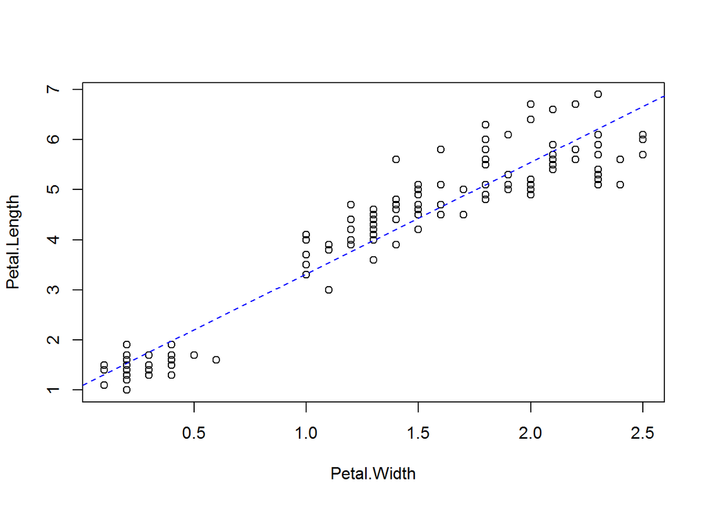

```r
plot(Petal.Length~Petal.Width, iris)
abline(mod_a, col='blue',lty=2)
```

```r
stat(mod_a) # r-squared
```

```
## [1] 0.9271098
```

Target shuffle our model

```r
n=1e3
results_a = tShuffle(n, iris$Petal.Width, iris$Petal.Length, fitModel, stat, replace=TRUE)
```

Visualize results of target shuffling

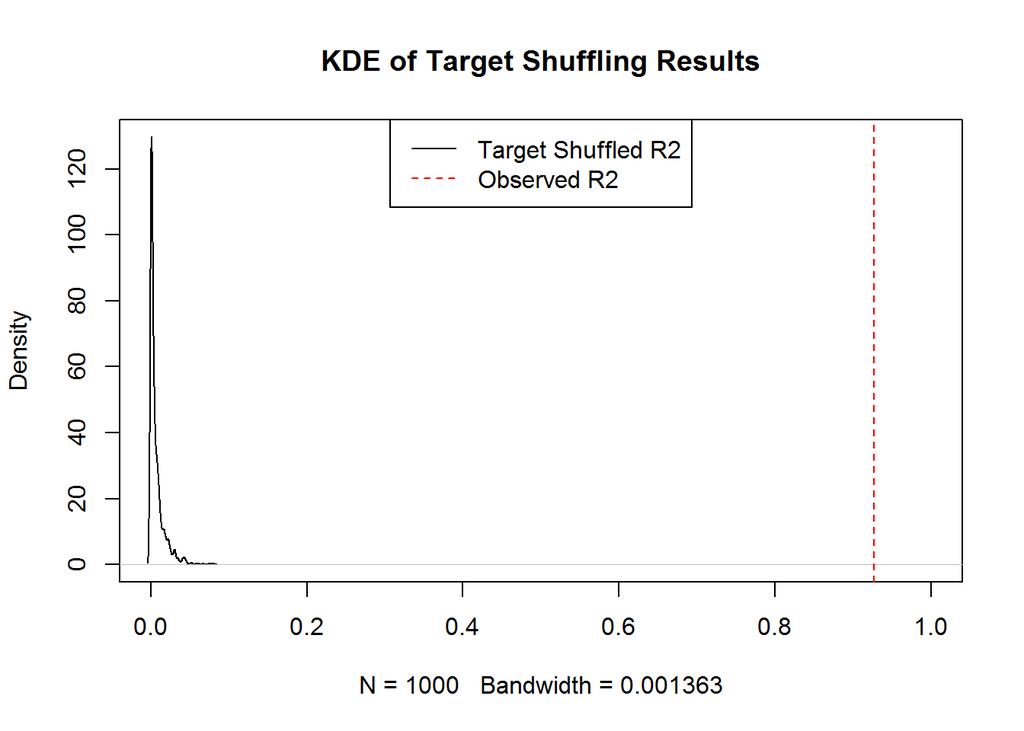

```r
plot(density(results_a$values), xlim=c(0,1), main='KDE of Target Shuffling Results')
abline(v=stat(mod_a), lty=2, col='red')
legend('top', c('Target Shuffled R2', 'Observed R2'), lty=1:2, col=1:2)
```

Compare estimated p-value with observed

```r
print(paste("Estimated p-value:", results_a$est_pval))
```

```
## [1] "Estimated p-value: 0"
```

```r
print(paste("Observed p-value:",extract_pval(mod_a)))
```

```
## [1] "Observed p-value: 4.67500390732776e-86"
```

```r
summary(results_a$values)
```

```
##      Min.   1st Qu.    Median      Mean   3rd Qu.      Max.
## 2.000e-08 7.071e-04 2.794e-03 6.873e-03 8.787e-03 7.990e-02
```

```r
#################
```

Let’s contrast these results with an attempt to fit a bad model.

```r
mod_b = lm(Sepal.Length~Sepal.Width, iris)
summary(mod_b)
```

```
##
## Call:
## lm(formula = Sepal.Length ~ Sepal.Width, data = iris)
##
## Residuals:
##     Min      1Q  Median      3Q     Max
## -1.5561 -0.6333 -0.1120  0.5579  2.2226
##
## Coefficients:
##             Estimate Std. Error t value Pr(>|t|)
## (Intercept)   6.5262     0.4789   13.63   <2e-16 ***
## Sepal.Width  -0.2234     0.1551   -1.44    0.152
## ---
## Signif. codes:  0 '***' 0.001 '**' 0.01 '*' 0.05 '.' 0.1 ' ' 1
##
## Residual standard error: 0.8251 on 148 degrees of freedom
## Multiple R-squared:  0.01382,    Adjusted R-squared:  0.007159
## F-statistic: 2.074 on 1 and 148 DF,  p-value: 0.1519
```

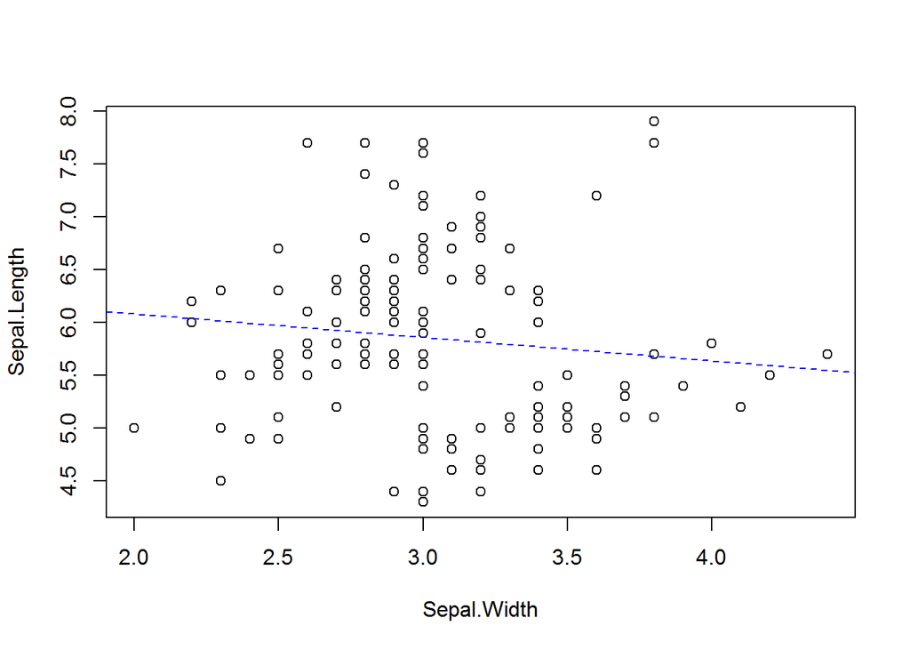

```r
plot(Sepal.Length~Sepal.Width, iris)
abline(mod_b, col='blue', lty=2)
```

```r
stat(mod_b)
```

```
## [1] 0.01382265
```

Target shuffle our model

```r
results_b = tShuffle(n, iris$Sepal.Width, iris$Sepal.Length, fitModel, stat, replace=TRUE)
```

Visualize results of target shuffling

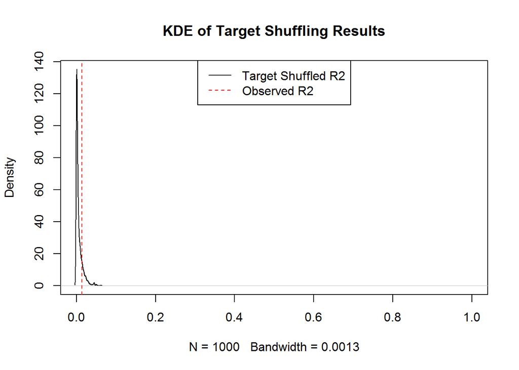

```r
plot(density(results_b$values), xlim=c(0,1), main='KDE of Target Shuffling Results')
abline(v=stat(mod_b), lty=2, col='red')
legend('top', c('Target Shuffled R2', 'Observed R2'), lty=1:2, col=1:2)
```

```r
print(paste("Estimated p-value:", results_b$est_pval))
```

```
## [1] "Estimated p-value: 0.137"
```

```r
print(paste("Observed p-value:",extract_pval(mod_b)))
```

```
## [1] "Observed p-value: 0.151898260711447"
```

```r
summary(results_b$values)
```

```
##      Min.   1st Qu.    Median      Mean   3rd Qu.      Max.
## 1.000e-08 6.260e-04 2.560e-03 6.051e-03 8.333e-03 6.113e-02
```

Let’s run a little experiment to observe how quickly the target shuffled significance on the r^2 statistics converges to the analytic p-value for the model, and see if incorporating bootstrap resampling in our target shuffle makes any difference.

```r
run_experiment = function(x, y, k, fitModel, stat, ...){
  mod = lm(y~x)
  results = tShuffle(k, x, y, fitModel, stat, ...)

  p_sim = results$est_pval #sum(stat(mod) < results)/length(results)
  num = cumsum(stat(mod) < results$values)
  denom = 1: length(results$values)
  plot(denom,
       num/denom,
       type='l',
       main="Running simulated p-value",
       xlab="Iteration",
       ylab="Simulated p-value"
  )
  abline(h=p_sim, col='red', lty=2)
  p_anlyt = extract_pval(mod) #unlist(anova(mod)[c("Pr(>F)")])[1]
  abline(h=p_anlyt, col='blue', lty=2)
  legend('topright', c('Running estimated p-value','Final estimated p-value', 'Observed analytic p-value'),
         lty=c(1,2,2), col=c(1:2,'blue')
  )

  abs_error=abs(num/denom - p_anlyt)

  plot(denom, abs_error,
       type='l',
       main="Convergence to analytic p-value",
       xlab="Iteration",
       ylab="Absolute Error (|p_sim - p_anlyt|)",
       ylim=c(0,.05)
  )
  return(list(results=results, p_sim=p_sim, p_analytic=p_anlyt, abs_error=abs_error))
}
```

Generic Target Shuffling

```r
exp_f = run_experiment(iris$Sepal.Width, iris$Sepal.Length, n, fitModel, stat, replace=FALSE)
```

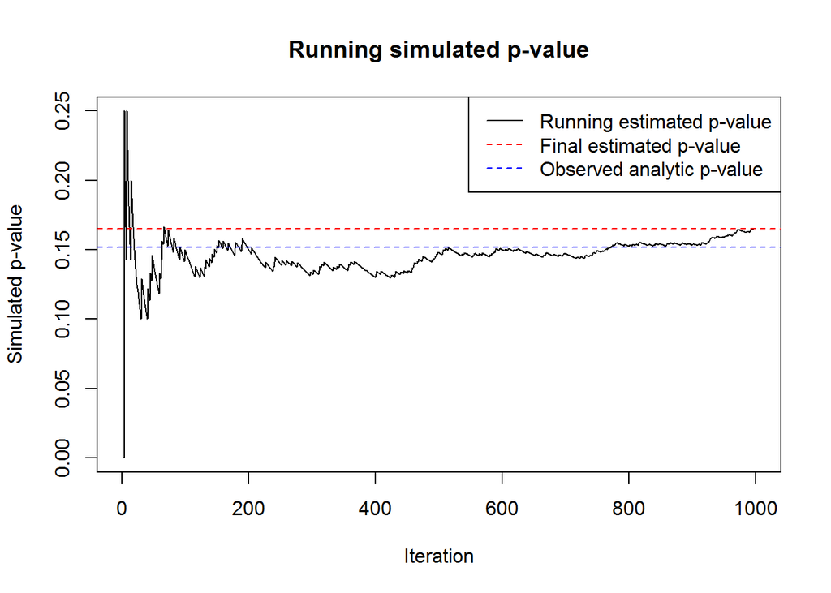

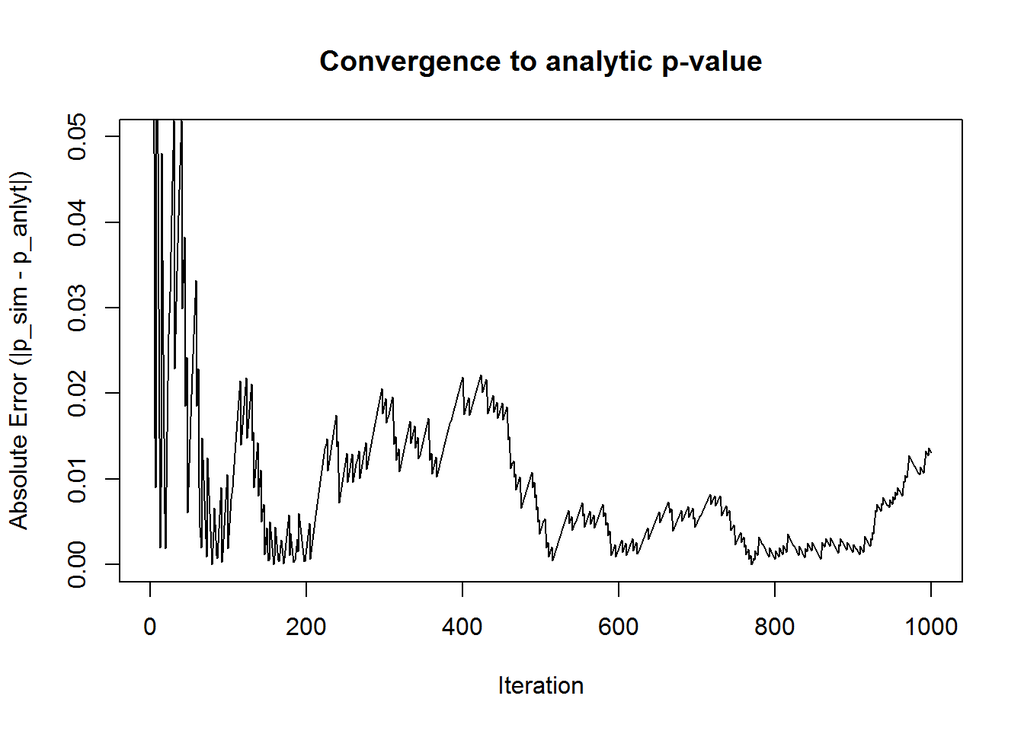

```r
exp_f$p_sim; exp_f$p_analytic
```

```
## [1] 0.165
```

```
##   Pr(>F)1
## 0.1518983
```

Bootstrapped Target Shuffling

```r
exp_t = run_experiment(iris$Sepal.Width, iris$Sepal.Length, n, fitModel, stat, replace=TRUE)
```

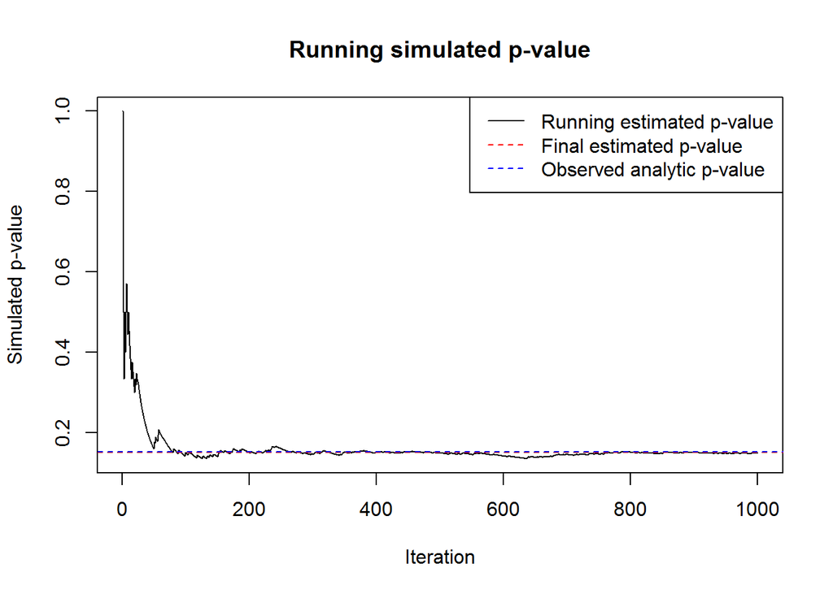

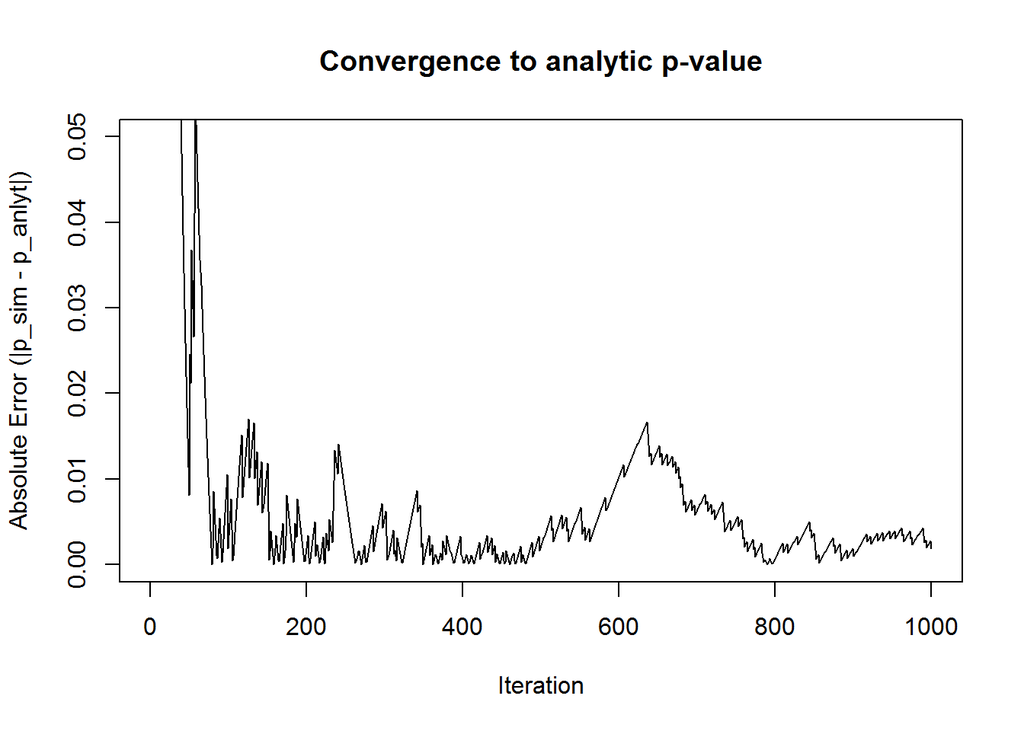

```r
exp_t$p_sim; exp_t$p_analytic
```

```
## [1] 0.15
```

```
##   Pr(>F)1
## 0.1518983
```

It appears that incorporating bootstrapping with target shuffling probablydoesn’t really make much of a difference.

**Class Imbalance**

Target shuffling is especially useful in situations where the analytic p-value may not be representative of the true null distribution. A textbook exaple is in the case of significant class imbalance: a naive model will be able to achieve significant accuracy by effectively predicting that any input will be of the majority class. To demonstrate, let’s construct a dataset with two randomly distributed classes (i.e. inseparable given the available features) where one class is a significant minority relative to the other.

```r
n=1e3
p=0.05
x = runif(n)
y = rbinom(n,1,p)

table(y)/n
```

```
## y
##     0     1
## 0.954 0.046
```

Since we know that there is no conditional relationship between `x` and `y`, we know that, theoretically, trying to train a logistic regression on this data would be fruitless. But the class imbalance will give us deceptive results.

```r
fitModel_log = function(x,y){
  glm(y~x, data.frame(x,y),family='binomial')
}

accuracy = function(mod, Y=y){
  mean(Y == (predict(mod)>0) )
}


mod_c = fitModel_log(x,y)
acc = accuracy(mod_c)
print(paste("Accuracy:",acc))
```

```
## [1] "Accuracy: 0.954"
```

Wow! That’s an accurate model! But does it mean we’re really achieving good class separation? Let’s target shuffle it and see how significant this result really is.

```r
n=1e3
```

```r
results_c = tShuffle(n, x, y, fitModel_log, accuracy, replace=TRUE)
```

Visualize results of target shuffling

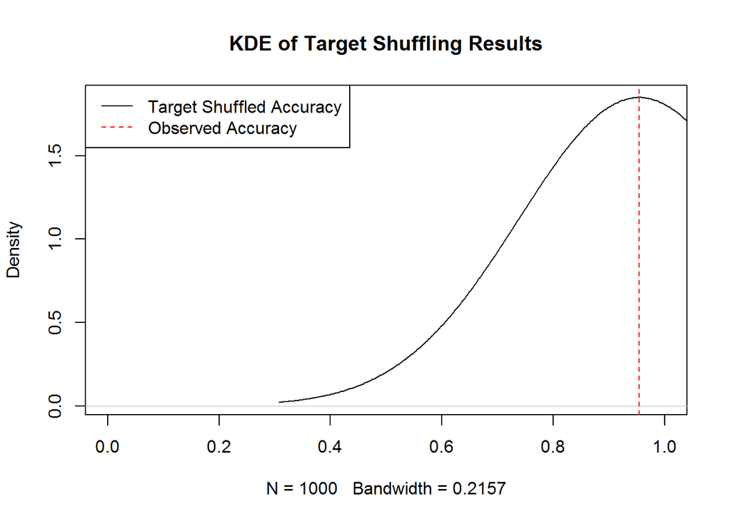

```r
plot(density(results_c$values), xlim=c(0,1), main='KDE of Target Shuffling Results')
abline(v=accuracy(mod_c), lty=2, col='red')
legend('topleft', c('Target Shuffled Accuracy', 'Observed Accuracy'), lty=1:2, col=1:2)
```

Our model sure doesn’t look so special now.

```r
print(paste("Estimated p-value:", results_c$est_pval))
```

```
## [1] "Estimated p-value: 1"
```

```r
summary(results_c$values)
```

```
##    Min. 1st Qu.  Median    Mean 3rd Qu.    Max.
##   0.954   0.954   0.954   0.954   0.954   0.954
```

### Bootstrap

Target shuffling gives us a distribution over the null hypothesis. The *bootstrap* technique gives us a distribution over model solutions and/or evaluation statistics, AKA distributions over the alternative hypothesis. We estimated our p-value by comparing a unique model solution against our distribution of null hypotheses, but we can actually infer a distribution over p-values, giving us a confidence interval on our p-value (!!!)

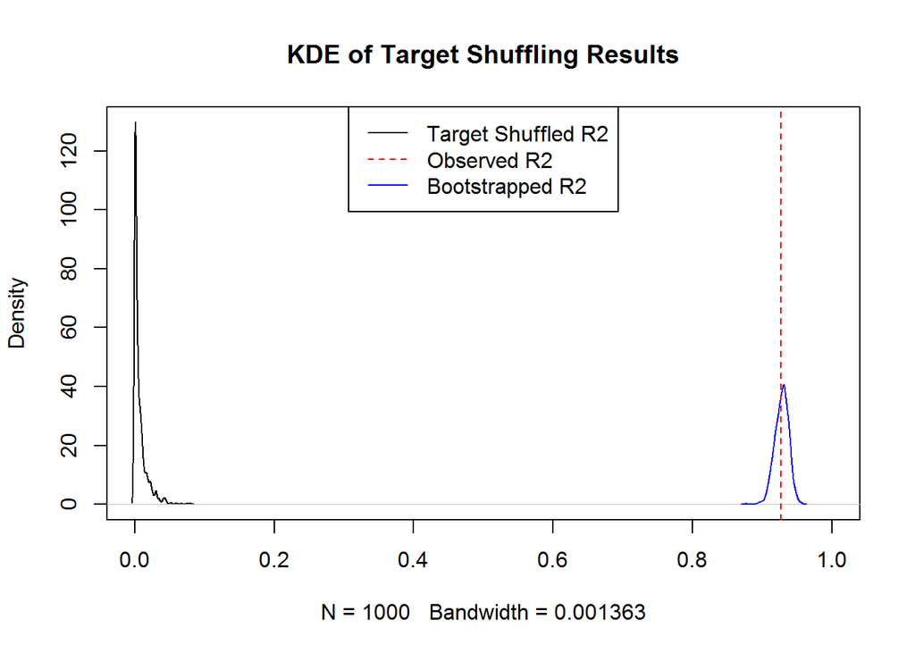

```r
boot_sample = function(x){
  n = nrow(x)
  ix = sample(n, replace=TRUE)
  x[ix,]
}

boot_stat = function(k, x, y, fitModel, stat){
  results = rep(NULL, k)
  full_dat = cbind(y,x)
  for(i in 1:k){
    boot_dat = boot_sample(full_dat)
    xb = boot_dat[,2:(NCOL(x)+1)]
    yb = boot_dat[,1]
    results[i] = stat(fitModel(xb, yb))
  }
  results
}

# results_a = tShuffle(n, iris$Petal.Width, iris$Petal.Length, fitModel, stat, replace=TRUE)
boot_r2 = boot_stat(n, iris$Petal.Width, iris$Petal.Length, fitModel, stat)


plot(density(results_a$values), xlim=c(0,1), main='KDE of Target Shuffling Results')
lines(density(boot_r2), col='blue')
abline(v=stat(mod_a), lty=2, col='red')
legend('top', c('Target Shuffled R2', 'Observed R2', 'Bootstrapped R2'), lty=c(1,2,1), col=c(1,'red', 'blue'))
```

I like this. Let’s wrap the whole process.

```r
simulate_distributional_hypothesis_test = function(k, x, y, fitModel, stat, plt=TRUE){
  null_dist = tShuffle(k, x, y, fitModel, stat, replace=TRUE)
  alt_dist  = boot_stat(k, x, y, fitModel, stat)
  mod = fitModel(x,y)
  obs_stat = stat(mod)
  p_dist = sapply(alt_dist, function(v) 1 - mean(v>null_dist$values))
  p_thsuffle = null_dist$est_pval
  if(plt){
    plot(density(null_dist$values), xlim=range(c(null_dist, alt_dist)), main="Target shuffling vs. bootstrap")
    lines(density(alt_dist), col='blue')
    abline(v=obs_stat, lty=2, col='red')
    legend('top', c('Target Shuffled stat', 'Observed stat', 'Bootstrapped stat'), lty=c(1,2,1), col=c(1,'red', 'blue'))
  }
  list(null_hypothesis=null_dist$values,
       alternative_hypothesis=alt_dist,
       fitted_stat=obs_stat,
       fitted_model=mod,
       fitted_pval=extract_pval(mod),
       pvalue_distribution=p_dist,
       tshuffle_pvalue=p_thsuffle)
}
```

Where we have wel defined significance, the two distributions are well separated.

```r
sim_dist = simulate_distributional_hypothesis_test(n, iris$Petal.Width, iris$Petal.Length, fitModel, stat)
```

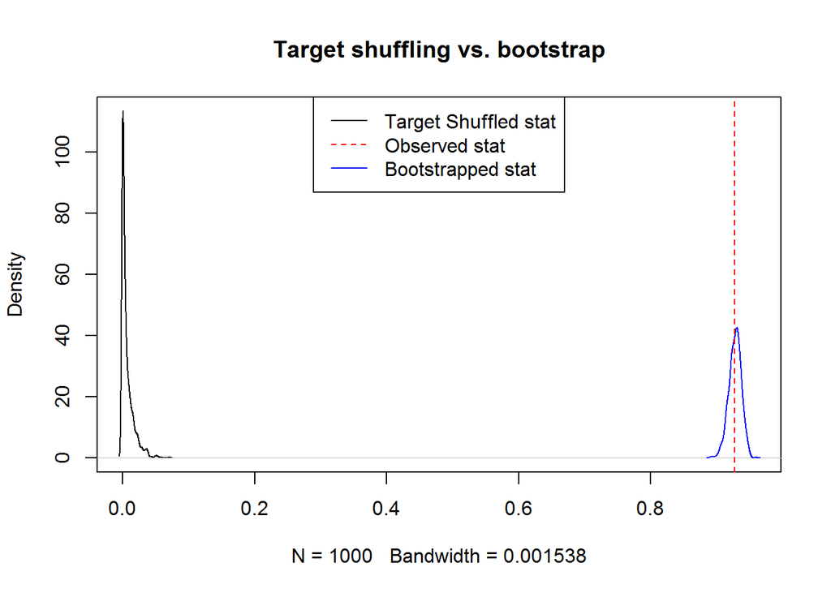

Where we don’t have strong significance, there is overlap in the target shuffled and bootstrapped distributions, and we get a range (distribution) of pvalues

```r
sim_dist2 = simulate_distributional_hypothesis_test(n, iris$Sepal.Width, iris$Sepal.Length, fitModel, stat)
```

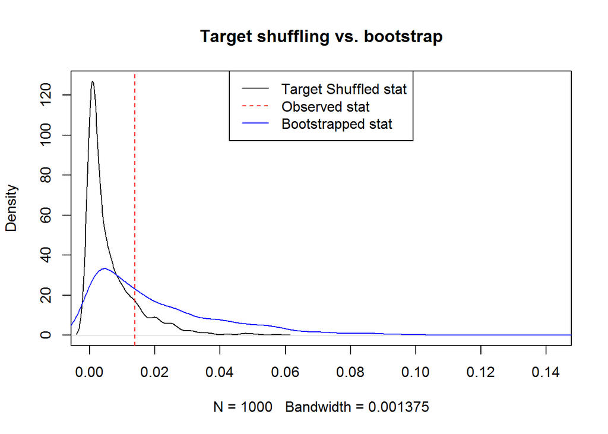

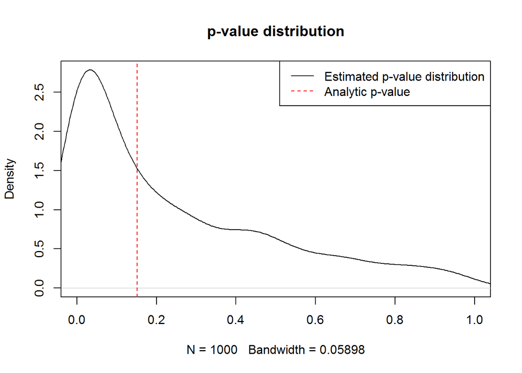

```r
plot(density(sim_dist2$pvalue_distribution), main="p-value distribution", xlim=c(0,1))
abline(v=sim_dist2$fitted_pval, lty=2, col="red")
legend('topright', c('Estimated p-value distribution', 'Analytic p-value'), lty=c(1,2), col=c(1,'red'))
```

The median of our estimation distribution is pretty close to our analytic and target-shuffled p-values.

```r
sim_dist2$fitted_pval
```

```
##   Pr(>F)1
## 0.1518983
```

```r
sim_dist2$tshuffle_pvalue
```

```
## [1] 0.142
```

```r
quantile(sim_dist2$pvalue_distribution, c(.05, .5, .95))
```

```
##      5%     50%     95%
## 0.00000 0.14450 0.82105
```

interesting, the mode and mean are not.

```r
dens = density(sim_dist2$pvalue_distribution)
dens$x[which.max(dens$y)] # pval distr mode
```

```
## [1] 0.03235829
```

```r
mean(sim_dist2$pvalue_distribution) # pval distr mean
```

```
## [1] 0.242242
```

being a bit more traditional, let’s look at the distribution of the difference between the null and the alternative hypothesis. If this distribution contains 0 at our significance level of interest, we fail to reject the null.

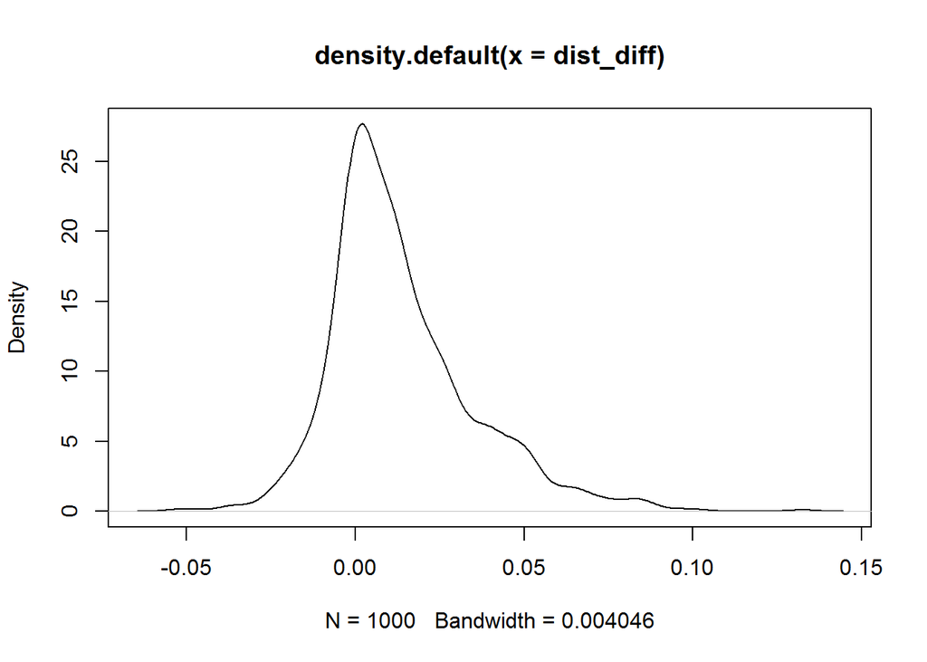

```r
dist_diff = sim_dist2$alternative_hypothesis - sim_dist2$null_hypothesis
plot(density(dist_diff))
```

```r
quantile(dist_diff, c(.05, .5, .95))
```

```
##           5%          50%          95%
## -0.013074066  0.009019263  0.053648221
```

### Discussion

This obviously invites the question: how useful is a confidence bound about a p-value? I’ve certainly never seen this approach used anywhere, but at face value it doesn’t strike me as completely useless. In fact, having computed this, this seems like a good way of doing things. Why shouldn’t we calculate bounds about our p-values? How useful is a p-value, or really any statistic, in complete isolation? Although this seems reasonable at first, I have to admit: I’m struggling to find real value in this range I’ve constructed. My initial result from target shuffling against a single point estimate for my statistics demonstrated that my model was not significant at a 10% threshold. Querying the p-value distribution told me that there are random models that are significant (the tail of the distribution that lies outside of the range of the target shuffled statistic) and there are random models that are stringly not significant (the distributional overlap). So what?